# Covid-19-CA-Counties

aaron mamula

6/2/2020

The objective here is to make some informative maps loosely guided by the LA Times Covid-Tracker which I really like:

https://www.latimes.com/projects/california-coronavirus-cases-tracking-outbreak/

I'm going to illustrate a static map using the `sf` package and `ggplot` with `geom_sf` to display a map of California counties colored by the number of new Covid-19 cases in the past 2 weeks.

## Data Wrangling

The data wrangling steps are:

1. Get the data on daily Covid-19 cases by county in the U.S. These data are available in a few places but I'm getting them from a GitHub repository that the NY Times set up.
2. Get a shapefile with county boundaries. I use the Census Bureau's TIGER Data Mart for this
3. I reorganize the Covid-19 case data. There are certainly more elegant ways to do this...what I have here is a little hacky but it works.

```r
# 1st get the county-level case data
#covid.county <- read.csv('data/us-county.csv')
covid.county <- read.csv("https://raw.githubusercontent.com/nytimes/covid-19-data/master/us-counties.csv")

# Next get the county boundaries from Census TIGER Lines and change the county field name
county.lines <- st_read('data/shapefiles/tl_2019_us_county/tl_2019_us_county.shp') %>%
                 mutate(county=NAME)
ca.lines <- county.lines %>% filter(STATEFP=='06')
str(ca.lines)
```

```
## Classes 'sf' and 'data.frame':   58 obs. of  19 variables:
##  $ STATEFP : chr  "06" "06" "06" "06" ...
##  $ COUNTYFP: chr  "091" "067" "083" "009" ...
##  $ COUNTYNS: chr  "00277310" "00277298" "00277306" "01675885" ...
##  $ GEOID   : chr  "06091" "06067" "06083" "06009" ...
##  $ NAME    : chr  "Sierra" "Sacramento" "Santa Barbara" "Calaveras" ...
##  $ NAMELSAD: chr  "Sierra County" "Sacramento County" "Santa Barbara County" "Calaveras County" ...
##  $ LSAD    : chr  "06" "06" "06" "06" ...
##  $ CLASSFP : chr  "H1" "H1" "H1" "H1" ...
##  $ MTFCC   : chr  "G4020" "G4020" "G4020" "G4020" ...
##  $ CSAFP   : chr  NA "472" NA NA ...
##  $ CBSAFP  : chr  NA "40900" "42200" NA ...
##  $ METDIVFP: chr  NA NA NA NA ...
##  $ FUNCSTAT: chr  "A" "A" "A" "A" ...
##  $ ALAND   : num  2.47e+09 2.50e+09 7.08e+09 2.64e+09 4.77e+09 ...
##  $ AWATER  : num  2.33e+07 7.54e+07 2.73e+09 4.38e+07 9.47e+08 ...
##  $ INTPTLAT: chr  "+39.5769252" "+38.4500161" "+34.5370572" "+38.1838996" ...
##  $ INTPTLON: chr  "-120.5219926" "-121.3404408" "-120.0399729" "-120.5614415" ...
##  $ geometry:sfc_MULTIPOLYGON of length 58; first list element: List of 1
##   ..$ :List of 1
##   .. ..$ : num [1:4984, 1:2] -121 -121 -121 -121 -121 ...
##   ..- attr(*, "class")= chr [1:3] "XY" "MULTIPOLYGON" "sfg"
##  $ county  : chr  "Sierra" "Sacramento" "Santa Barbara" "Calaveras" ...
##  - attr(*, "sf_column")= chr "geometry"
##  - attr(*, "agr")= Factor w/ 3 levels "constant","aggregate",..: NA NA NA NA NA NA NA NA NA NA ...
##   ..- attr(*, "names")= chr [1:18] "STATEFP" "COUNTYFP" "COUNTYNS" "GEOID" ...
```

```r
# Next get 2019 county population and fix the names
CA.pop <- read.csv('data/CA-county-pop.csv')
CA.pop$county <- trimws(gsub("County, California","",CA.pop$County))
```

```r
#--------------------------------------------------------------------
# Next, roll the case counts up to the most recent 14-day window
# the daily data are cumulative. I think the easiest way to do this is
# to do a 14-period difference

# first thing I'm going to do is expand the data set because not every county
# is in the data for every day
first.day <- min(as.Date(covid.county$date))
last.day <- max(as.Date(covid.county$date))

ca.cases <- covid.county %>% filter(state=='California')

# create a dataframe containing all days and all California counties
ca.county.alldays <- data.frame(rbindlist(lapply(unique(CA.pop$county),function(x){
  return(data.frame(county=x,
                    state=unique(ca.cases$state[ca.cases$county==x]),
                    fips=unique(ca.cases$fips[ca.cases$county==x]),
                    date=seq.Date(from=first.day,to=last.day,by="day"),cases=0,deaths=0))
})))

# I'm rearranging the data to be new cases each day rather than cumulative cases becauses
# it's a little easier for me to deal with
ca.cases <- ca.cases %>%
            mutate(date=as.Date(date,format="%Y-%m-%d")) %>%
            arrange(county,date) %>%
            group_by(county) %>%
            mutate(daily_new_cases=cases-lag(cases),
                   daily_new_cases=ifelse(row_number()==1,cases,daily_new_cases),
                   daily_new_deaths=deaths-lag(deaths),
                   daily_new_deaths=ifelse(row_number()==1,deaths,daily_new_deaths))


ca.cases <- ca.county.alldays %>% left_join(ca.cases,by=c('county','state','fips','date')) %>%
              mutate(daily_new_cases=ifelse(is.na(daily_new_cases),cases.x,daily_new_cases),
                     daily_new_deaths=ifelse(is.na(daily_new_deaths),deaths.x,daily_new_deaths)) %>%
              select(county,date,state,fips,cases.y,deaths.y,daily_new_cases,daily_new_deaths)
```

```r
# now we create the cumulative cases and cumulative deaths again
ca.cases <- ca.cases %>% arrange(county,date) %>% group_by(county) %>%
              mutate(cum_daily_cases=cumsum(daily_new_cases),
                     cum_daily_death=cumsum(daily_new_deaths),
                     new_2wk=cum_daily_cases-lag(cum_daily_cases,14),
                     new_2wk_deaths=cum_daily_death-lag(cum_daily_death,14),
                     change_from_last_2wks_cases=new_2wk-lag(new_2wk,14),
                     diff=ifelse(change_from_last_2wks_cases<0,"2 Week New Cases Decreasing",
                                 ifelse(change_from_last_2wks_cases>0,"2 Week New Cases Increasing","No change")))
```

```r
#--------------------------------------------------------------
# join the case counts to population data

#the map is going to be a point-in-time map so we need the
# data frame to be a single date

ca.cases <- ca.cases %>% left_join(CA.pop,by=c('county')) %>%
              mutate(cases_per_100k=new_2wk/(Pop/100000),
                     deaths_per_100k=new_2wk_deaths/(Pop/100000)) %>%
               arrange(county,date) %>% group_by(county) %>%
                filter(row_number()==n())

ca.lines <- county.lines %>% filter(STATEFP=='06') %>%
              left_join(ca.cases,by=c('county'))
```

## A Static County Map for CA

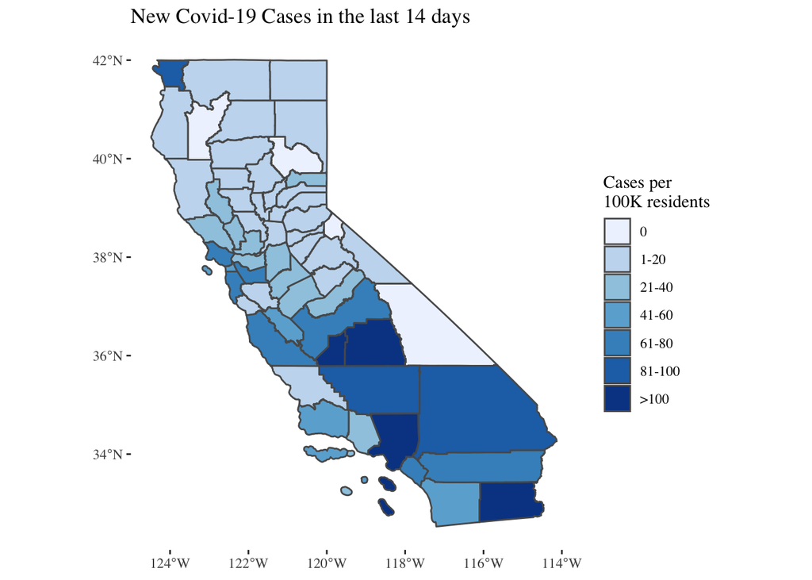

```r
# for aestetics I'm going to reduce the variance by binning the data
ca.lines <- ca.lines %>% mutate(cases_per_100k_D = ifelse(cases_per_100k == 0 ,0,
                                                   ifelse(cases_per_100k>0 & cases_per_100k<21,"1-20",
                                                   ifelse(cases_per_100k>20 & cases_per_100k<41,"21-40",
                                                   ifelse(cases_per_100k>40 & cases_per_100k<61,"41-60",
                                                   ifelse(cases_per_100k>60 & cases_per_100k<81,"61-80",
                                                   ifelse(cases_per_100k>80 & cases_per_100k<101,"81-100",
                                                  ifelse(cases_per_100k>100,">100",NA))))))))

ca.lines$cases_per_100k_D <- factor(ca.lines$cases_per_100k_D,
                                    levels=c("0","1-20","21-40","41-60","61-80","81-100",">100"))

county.list <- ca.lines %>% filter(county %in% c("Kings","Imperial","Los Angeles"))
ggplot(ca.lines) + geom_sf(aes(fill=cases_per_100k_D)) +
   #geom_sf_label_repel(data=county.list,aes(label = county),
    #                    force = 100, nudge_x = -2, seed = 10) +
  theme_tufte() + scale_fill_brewer(name="Cases per\n100K residents") +
  ggtitle("New Covid-19 Cases in the last 14 days")
```

Let's add an informative bar chart. I sometimes find the aestetics of Choropleth maps challenging. Specifically, I find it difficult to add baseline info, or spatial context, in a way that doesn't compromise the minimalist aestetic. In the map above I like the clean display of change in cases over space...but I don't like that I can't really label the counties without crowding the visual.

If I want to convey more granular information about specific counties, I can add a bar chart to the mix. This is a nice way to allow readers to dive a little deeper into the general spatial patterns they can see on the map:

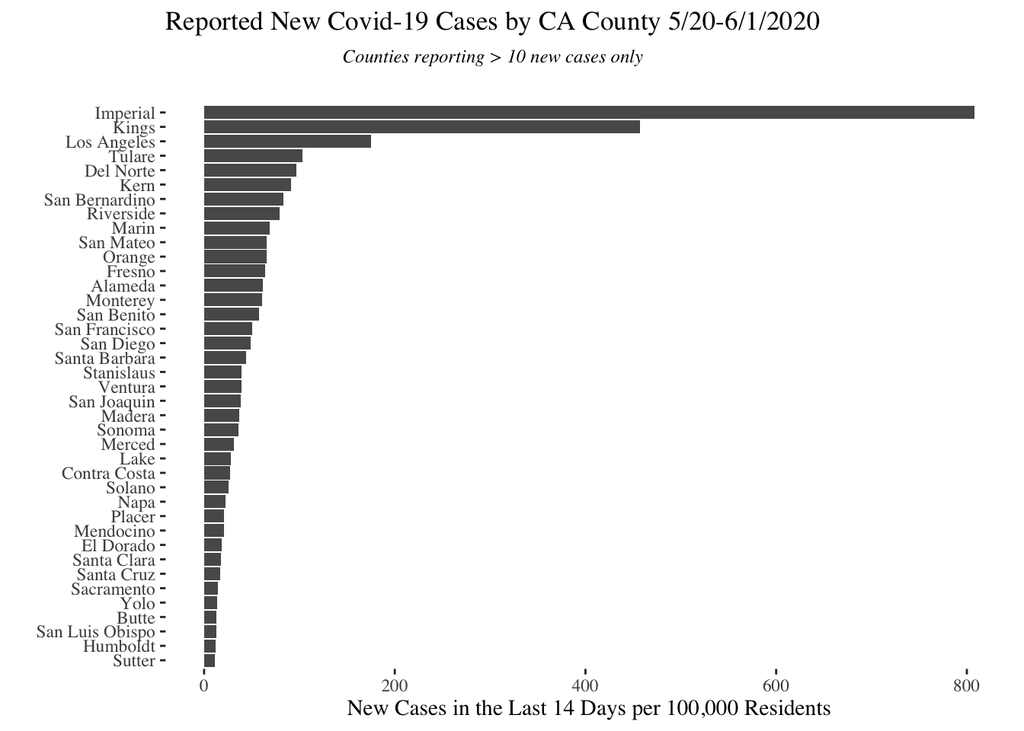

```r
# display cases per 100k residents with population

# reorder county names by cases
ggplot(ca.cases %>% filter(new_2wk>10),aes(x=reorder(county,cases_per_100k),y=cases_per_100k)) + geom_bar(stat='identity') + coord_flip() +
  ylab("New Cases in the Last 14 Days per 100,000 Residents") + xlab("")  +
  theme_tufte()  + ggtitle(expression(atop("Reported New Covid-19 Cases by CA County 5/20-6/1/2020", atop(italic("Counties reporting > 10 new cases only"), ""))))
```

## An Interactive Map using Tmap/Leaflet

Note: currently, I'm having trouble installing the tmap package to R Studio Cloud. We can go through this on my local R Studio Installation.

```r
# try an example with tm/leaflet
library(tmap)
library(tmaptools)

# using this tutorial as a guide:
# http://zevross.com/blog/2018/10/02/creating-beautiful-demographic-maps-in-r-with-the-tidycensus-and-tmap-packages/#part-2-creating-beautiful-maps-with-tmap

# for this example I want to add one more dimension:
# whether or not the new 2 week case count increased or decreased
# from the previous week


carto <- "https://cartodb-basemaps-{s}.global.ssl.fastly.net/light_all/{z}/{x}/{y}{r}.png"


my_map <- tm_basemap(carto) +
  tm_shape(ca.lines) +
  tm_borders(col="azure2") +
  tm_bubbles('cases_per_100k',
             col="diff",
             palette=c("coral2","aquamarine3","grey"),
              popup.vars=c("County: " = "county", "New Cases per 100k Residents: " = "cases_per_100k"))


tmap_leaflet(my_map)
```

[output not shown]